# Project- 3 : Thera Bank Modelling

# -----------------------Naive Bayes ------------------------------------------------

### We first run a single iteration of the model with a random seed and then perform multiple iterations to get an average accuracy score.

### Training the model

```python
# Creating the classifier
Classifier_NB = GaussianNB()
```

```python
Classifier_NB.fit(X_train,y_train)
```

```
GaussianNB(priors=None, var_smoothing=1e-09)
```

### Predicting the test results

```python
y_pred_NB = Classifier_NB.predict(X_test)
```

### Evaluating the accuracy

```python
NB_score = Classifier_NB.score(X_test,y_test)
NB_score
# ~89% Accuracy in test dataset
```

```
0.8906666666666667
```

### Printing the confusion matrix and classification report for class level analysis

```python
cm_NB = confusion_matrix(y_test,y_pred_NB)
print(cm_NB)
```

```
[[1251  109]
 [  55   85]]
```

```python
cr_NB = classification_report(y_test,y_pred_NB)
print(cr_NB)
# The classification report suggests that the model is likely to perform better in the case of
# people who don't accept loans more than the people who accept loans. This is due to the skewness
# in the availability of the data for the different classes of customers.
```

```
              precision    recall  f1-score   support

           0       0.96      0.92      0.94      1360
           1       0.44      0.61      0.51       140

   micro avg       0.89      0.89      0.89      1500
   macro avg       0.70      0.76      0.72      1500
weighted avg       0.91      0.89      0.90      1500
```

### Running multiple iterations of the model to get the average accuracy.

#### Here, no random seed is used to cover the variance in the dataset

```python
score_NB=[]
for i in range(10):
    X_bar_train,X_bar_test,y_bar_train,y_bar_test = train_test_split(X,y,test_size=0.30)
    iterative_NB = GaussianNB()
    iterative_NB.fit(X_bar_train,y_bar_train)
    score_NB.append(iterative_NB.score(X_bar_test,y_bar_test))
```

### Visualising the results

```
Mean accuracy :  0.8930000000000001
Standard Deviation : 0.006205732117253463
```

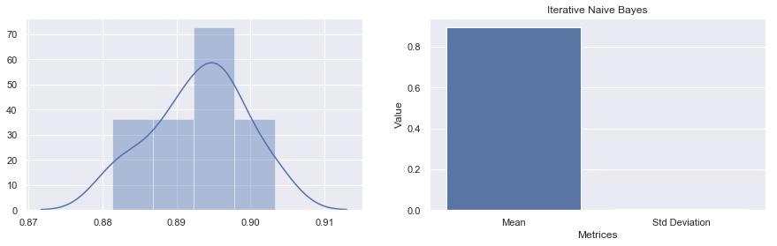

```python
fig,axes = plt.subplots(nrows=1,ncols=2,figsize=(15,4))
labels = ['Mean', 'Std Deviation']
metrix = [np.mean(score_NB),np.std(score_NB)]
sns.distplot(score_NB,ax=axes[0])
sns.barplot(x=labels,y=metrix,ax=axes[1])
plt.xlabel("Metrices")
plt.ylabel("Value")
plt.title("Iterative Naive Bayes")
print("Mean accuracy : ",np.mean(score_NB))
print("Standard Deviation :" ,np.std(score_NB))
```

# --------------------------------------K-NN-------------------------------------------------------

### We first run a single iteration of the model with a random seed and then perform multiple iterations to get an average accuracy score.

### In KNN, since it is a distance based algorithm, the standardization of the independent variables by using statistical techniques such as zscore is a good practice so that the algorithm doesn't get biased with the different range of values in different attributes.

```python
#Standardizing training set
def standardize_train(X):

    KNN_XT = pd.DataFrame()
    KNN_XT['Experience'] =zscore(X_train['Experience'])
    KNN_XT['Income'] =zscore(X_train['Income'])
    KNN_XT['Family'] =zscore(X_train['Family'])
    KNN_XT['CCAvg'] =zscore(X_train['CCAvg'])
    KNN_XT['Education_1'] =zscore(X_train['Education_1'])
    KNN_XT['Education_2'] =zscore(X_train['Education_2'])
    KNN_XT['Education_3'] =zscore(X_train['Education_3'])
    KNN_XT['Mortgage'] =zscore(X_train['Mortgage'])
    KNN_XT['Securities Account'] =zscore(X_train['Securities Account'])
    KNN_XT['CD Account'] =zscore(X_train['CD Account'])
    KNN_XT['Online'] =zscore(X_train['Online'])
    KNN_XT['CreditCard'] =zscore(X_train['CreditCard'])
    return KNN_XT
```

```python
#Standardizing test set
def standardize_test(X):
    KNN_XT2 = pd.DataFrame()
    KNN_XT2['Experience'] =zscore(X_test['Experience'])
    KNN_XT2['Income'] =zscore(X_test['Income'])
    KNN_XT2['Family'] =zscore(X_test['Family'])
    KNN_XT2['CCAvg'] =zscore(X_test['CCAvg'])
    KNN_XT2['Education_1'] =zscore(X_test['Education_1'])
    KNN_XT2['Education_2'] =zscore(X_test['Education_2'])
    KNN_XT2['Education_3'] =zscore(X_test['Education_3'])
    KNN_XT2['Mortgage'] =zscore(X_test['Mortgage'])
    KNN_XT2['Securities Account'] =zscore(X_test['Securities Account'])
    KNN_XT2['CD Account'] =zscore(X_test['CD Account'])
    KNN_XT2['Online'] =zscore(X_test['Online'])
    KNN_XT2['CreditCard'] =zscore(X_test['CreditCard'])
    return KNN_XT2
```

### Model WITHOUT standardization

### Training the model

```python
# Creating the classifier
classifier_KNN = KNeighborsClassifier(n_neighbors=17, weights='distance')
classifier_KNN.fit(X_train,y_train) #Non-standardized training data
```

```
KNeighborsClassifier(algorithm='auto', leaf_size=30, metric='minkowski',
           metric_params=None, n_jobs=None, n_neighbors=17, p=2,
           weights='distance')
```

### Predicting the test results

```python
y_pred_KNN = classifier_KNN.predict(X_test)
```

### Evaluating the accuracy

```python
knn_score = classifier_KNN.score(X_test,y_test)
print(knn_score)
# ~90.53% accuracy
```

```
0.9053333333333333
```

### Printing the confusion matrix and classification report for class level analysis

```python
cm_KNN = confusion_matrix(y_test,y_pred_KNN)
print(cm_KNN)
```

```
[[1320   40]
 [ 102   38]]
```

```python
cr_KNN = classification_report(y_test,y_pred_KNN)
print(cr_KNN)
# The classification report suggests that the model is likely to perform better in the case of
# people who don't accept loans more than the people who accept loans. This is due to the skewness
# in the availability of the data for the different classes of customers.
```

```
              precision    recall  f1-score   support

           0       0.93      0.97      0.95      1360
           1       0.49      0.27      0.35       140

   micro avg       0.91      0.91      0.91      1500
   macro avg       0.71      0.62      0.65      1500
weighted avg       0.89      0.91      0.89      1500
```

### Model WITH standardization

```python
KNN_XT = standardize_train(X_train)
KNN_XT2 = standardize_test(X_test)
```

### Training the model

```python
# Creating the classifier
classifier_KNN_S = KNeighborsClassifier(n_neighbors=17, weights='distance')
classifier_KNN_S.fit(KNN_XT,y_train) # Standardized training data
```

```
KNeighborsClassifier(algorithm='auto', leaf_size=30, metric='minkowski',
           metric_params=None, n_jobs=None, n_neighbors=17, p=2,
           weights='distance')
```

### Predicting the test results

```python
y_pred_KNN_S = classifier_KNN_S.predict(KNN_XT2) #Standardized test data
```

### Evaluating the accuracy

```python
knn_standard_score = classifier_KNN_S.score(KNN_XT2,y_test)
print(knn_standard_score)
# ~95.73% accuracy
```

```
0.9573333333333334
```

### Printing the confusion matrix and classification report for class level analysis

```python
cm_KNN_S = confusion_matrix(y_test,y_pred_KNN_S)
print(cm_KNN_S)
```

```
[[1359    1]
 [  63   77]]
```

```python
cr_KNN_S = classification_report(y_test,y_pred_KNN_S)
print(cr_KNN_S)
# The classification report suggests that the model is likely to perform better in the case of
# people who don't accept loans more than the people who accept loans. This is due to the skewness
# in the availability of the data for the different classes of customers.
```

```
              precision    recall  f1-score   support

           0       0.96      1.00      0.98      1360
           1       0.99      0.55      0.71       140

   micro avg       0.96      0.96      0.96      1500
   macro avg       0.97      0.77      0.84      1500
weighted avg       0.96      0.96      0.95      1500
```

## Model Comparision

```
KNN Accuracy:  0.9053333333333333
Standardized KNN Accuracy :  0.9573333333333334
```

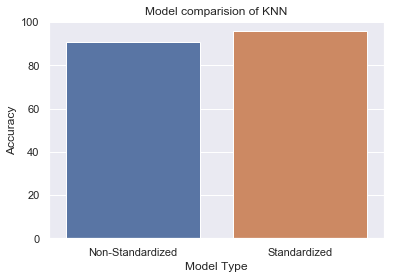

```python
label = ["Non-Standardized", "Standardized"]
value = [knn_score*100,knn_standard_score*100]
sns.barplot(x=label,y=value)
plt.xlabel("Model Type")
plt.ylabel("Accuracy")
plt.title("Model comparision of KNN")
print("KNN Accuracy: ", knn_score)
print("Standardized KNN Accuracy : ",knn_standard_score)
plt.show()
```

#### Here, no random seed is used to cover the variance in the dataset

```python
score_KNN=[]
for i in range(10):
    X_bar_train,X_bar_test,y_bar_train,y_bar_test = train_test_split(X,y,test_size=0.30)
    KNN_X_train = standardize_train(X_bar_train)
    KNN_X_test = standardize_test(X_bar_test)
    iterative_KNN = KNeighborsClassifier(n_neighbors=17, weights='distance')
    iterative_KNN.fit(KNN_X_train,y_bar_train)
    score_KNN.append(iterative_KNN.score(KNN_X_test,y_bar_test))
```

### Visualising the results

```
Mean accuracy :  0.9052666666666667
Standard Deviation : 0.007089585476050225
```

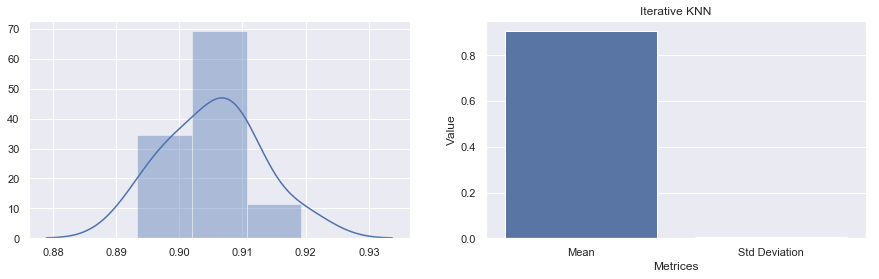

```python
fig,axes = plt.subplots(nrows=1,ncols=2,figsize=(15,4))
labels = ['Mean', 'Std Deviation']
metrix = [np.mean(score_KNN),np.std(score_KNN)]
sns.distplot(score_KNN,ax=axes[0])
sns.barplot(x=labels,y=metrix,ax=axes[1])
plt.xlabel("Metrices")
plt.ylabel("Value")
plt.title("Iterative KNN")
print("Mean accuracy : ",np.mean(score_KNN))
print("Standard Deviation :" ,np.std(score_KNN))
```

# ------------------------------Support Vector Machine ------------------------------------

### We first run a single iteration of the model with a random seed and then perform multiple iterations to get an average accuracy score.

### Training the model

```python
# Creating the classifier
classifier_SVM_rbf_kernel = svm.SVC(gamma='auto')
```

```python
classifier_SVM_rbf_kernel.fit(X_train,y_train)
```

```
SVC(C=1.0, cache_size=200, class_weight=None, coef0=0.0,
  decision_function_shape='ovr', degree=3, gamma='auto', kernel='rbf',
  max_iter=-1, probability=False, random_state=None, shrinking=True,
  tol=0.001, verbose=False)
```

### Predicting the test results

```python
y_pred_SVM_rbf = classifier_SVM_rbf_kernel.predict(X_test)
```

### Evaluating the accuracy

```python
svm_score_rbf = classifier_SVM_rbf_kernel.score(X_test,y_test)
svm_score_rbf
# ~91% Accuracy in test dataset
```

```
0.91
```

### Printing the confusion matrix and classification report for class level analysis

```python
cm_SVM = confusion_matrix(y_test,y_pred_SVM_rbf)
print(cm_SVM)
```

```
[[1351    9]
 [ 126   14]]
```

```python
cr_SVM = classification_report(y_test,y_pred_SVM_rbf)
print(cr_SVM)
# The classification report suggests that the model is likely to perform better in the case of
# people who don't accept loans more than the people who accept loans. This is due to the skewness
# in the availability of the data for the different classes of customers.
```

```
              precision    recall  f1-score   support

           0       0.91      0.99      0.95      1360
           1       0.61      0.10      0.17       140

   micro avg       0.91      0.91      0.91      1500
   macro avg       0.76      0.55      0.56      1500
weighted avg       0.89      0.91      0.88      1500
```

### Running multiple iterations of the model to get the average accuracy.

#### Here, no random seed is used to cover the variance in the dataset

```python
score_SVM=[]
for i in range(10):
    X_bar_train,X_bar_test,y_bar_train,y_bar_test = train_test_split(X,y,test_size=0.30)
    iterative_SVM = svm.SVC()
    iterative_SVM.fit(X_bar_train,y_bar_train)
    score_SVM.append(iterative_SVM.score(X_bar_test,y_bar_test))
```

### Visualising the results

```
Mean accuracy :  0.9076000000000001
Standard Deviation : 0.0050876757408903845
```

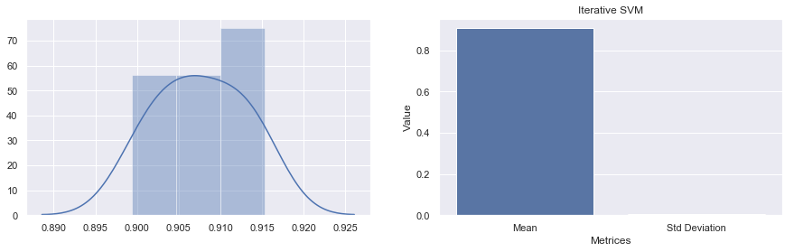

```python
fig,axes = plt.subplots(nrows=1,ncols=2,figsize=(15,4))
labels = ['Mean', 'Std Deviation']
metrix = [np.mean(score_SVM),np.std(score_SVM)]
sns.distplot(score_SVM,ax=axes[0])
sns.barplot(x=labels,y=metrix,ax=axes[1])
plt.xlabel("Metrices")
plt.ylabel("Value")
plt.title("Iterative SVM")
print("Mean accuracy : ",np.mean(score_SVM))
print("Standard Deviation :" ,np.std(score_SVM))
```